# hw3_erickson

## Assignment overview

In this assignment, you will perform image classification. You will experiment with support vector machines (using both linear and nonlinear kernels), as well as decision trees.

The data for this assignment comes from [CIFAR-10](http://www.cs.utoronto.ca/~kriz/cifar.html), an image dataset created at the University of Toronto. Images are labeled with one of 10 classes (see examples below). Some of the classes are similar (e.g., "automobile" and "truck"), though in this dataset, they are defined to be mutually exclusive.

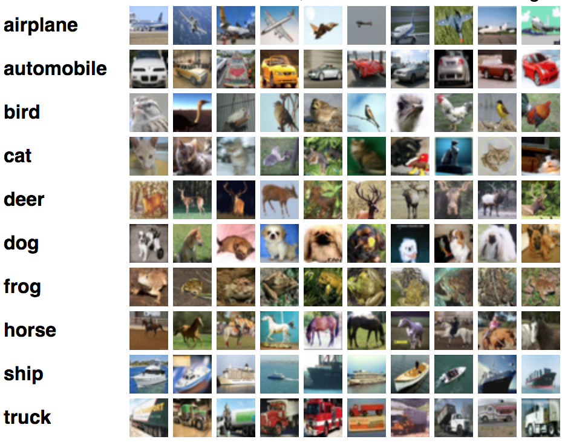

```python
from IPython.display import Image
Image('http://cmci.colorado.edu/classes/INFO-4604/data/hw3_example.png', width=500)
```

The images are tiny: 32x32 pixels. This makes it a difficult classification problem, because there is not a lot of detail in the images, but this is actually convenient for the purpose of this assignment, because the small size makes the data easier to work with computationally.

In general, image classification is a challenging machine learning problem, as well as a computationally intensive one. How to define and extract good features is an open challenge $-$ you'll see a little of that here. The CIFAR-10 data contains 50,000 images for training and 10,000 for testing, but for this assignment, you will work with only a sample of 1,000 training images and 1,000 test images. Your classifiers won't be as accurate as classifiers trained on all 50,000 instances, but it will be a lot more manageable to work with a small sample.

### What to hand in

You will submit the assignment on Canvas. **Please submit a .html or .pdf version of your assignment, and an .ipynb version of your file to Canvas**.

When writing code in this notebook, you are encouraged to create additional cells in whatever way makes the presentation more organized and easy to follow. You are allowed to import additional Python libraries.

### Submission policies

- **Errors:** It should be possible to run Kernel → Restart & Run All and run your submission without any errors. If your code does not run, you may not receive credit.
- **Collaboration:** You are allowed to work with a partner on this assignment. You are still expected to write up your own solution. Each individual must turn in their own submission, and list your collaborator after your name.
- **Late submissions:** Each student may use up to 5 late days over the semester. You have late days, not late hours. This means that if your submission is late by any amount of time past the deadline, then this will use up a late day. If it is late by any amount beyond 24 hours past the deadline, then this will use a second late, and so on. Once you have used up all late days, late assignments will be given at most 80% credit after one day and 60% credit after two days.

## Getting started

Begin by downloading and loading the data, stored in CSV format. The first column in each CSV file is the class label (the $y$ value), and the remaining columns are the feature values. The [`StandardScaler`](http://scikit-learn.org/stable/modules/generated/sklearn.preprocessing.StandardScaler.html) class is used to standardize the feature values using z-score normalization.

It may take a minute to run the cell below. In general, you'll notice that code in this assignment will take longer to execute than in HW2, even though the HW2 data had a similar number of instances and number of features. Why? The reason is that the image features are *dense*, meaning that all feature values need to be stored and used in the algorithm. In the tweets in HW2, the features were *sparse*, meaning that most of the feature values were simply $0$, and therefore didn't need to be stored in memory and in many cases could be skipped during computation in the learning algorithms.

```python
#libraries
import pandas as pd
import numpy as np
import matplotlib.pyplot as plt
import warnings
from IPython.display import display_html
from sklearn.preprocessing import StandardScaler
from sklearn.dummy import DummyClassifier
from sklearn.metrics import accuracy_score
from sklearn.svm import SVC
from sklearn.tree import DecisionTreeClassifier
from sklearn.ensemble import RandomForestClassifier
```

```python
scalar = StandardScaler()

print('Loading training data...')

# 'http://cmci.colorado.edu/classes/INFO-4604/data/cifar_raw_train.csv
df = pd.read_csv('cifar_raw_train.csv', header=None)

rawY = df.iloc[0:, 0].values
rawX = df.iloc[0:, 1:].values
scalar.fit(rawX)
rawX = scalar.transform(rawX)

print('...done.')
print('Loading test data...')

# 'http://cmci.colorado.edu/classes/INFO-4604/data/cifar_raw_test.csv'
df = pd.read_csv('cifar_raw_test.csv', header=None)

rawY_test = df.iloc[0:, 0].values
rawX_test = df.iloc[0:, 1:].values
scalar.fit(rawX_test)
rawX_test = scalar.transform(rawX_test)

print('...done.')
```

```
Loading training data...
...done.
Loading test data...
...done.
```

```python
# investigate data
rawX_test.shape, 3072/3
```

```
((1000, 3072), 1024.0)
```

### What do the columns mean?

The columns in the above CSV files correspond to color values of each pixel of the image (after the first column, which is the label). A 32x32 image has 1,024 pixels. The first 1,024 features are the red channel values of each pixel (values from 0 to 255), the second 1,024 features are the green channel values, and the last 1,024 features are the blue channel values, for a total of 3,072 features.

We refer to this as the "raw" data, because it simply encodes the image itself. You will load a different version of the dataset with more abstract features later on in this notebook.

### Establishing a baseline

Before experimenting with building classifiers, it can be good to come up with a "baseline" accuracy that you expect your classifiers to outperform. This is helpful for contextualizing how good your classifiers are doing.

`sklearn` provides a class called [`DummyClassifier`](http://scikit-learn.org/stable/modules/generated/sklearn.dummy.DummyClassifier.html) which implements a few different naive baselines that don't learn from features. In the code below, we use the `most_frequent` strategy, which simply creates a classifier that always predicts the majority class in the training data.

The ten classes in this dataset are roughly evenly distributed, so the majority class baseline only has an accuracy of around 10%. If you get an accuracy of 10% or lower in your experiments later, you'll know that your classifier is not learning anything useful.

```python
classifier = DummyClassifier(strategy='most_frequent')
classifier.fit(rawX, rawY)

print("Training accuracy: %0.6f" % accuracy_score(rawY, classifier.predict(rawX)))
print("Testing accuracy: %0.6f" % accuracy_score(rawY_test, classifier.predict(rawX_test)))
```

```
Training accuracy: 0.112000
Testing accuracy: 0.089000
```

## Problem 1: Support vector machines

We will begin by trying to classify the data using support vector machines (SVMs). For this problem, you will use `sklearn`'s [`SVC`](http://scikit-learn.org/stable/modules/generated/sklearn.svm.SVC.html) class, which implements a variety of SVM kernels. To handle multiple classes, `SVC` uses the "all pairs" algorithm (called "one-vs-one" in the `sklearn` documentation) for multiclass classification. (In contrast, the `SGDClassifier` you used in HW2 uses "one-vs-rest" by default, so you may get different results if you try to compare the two.)

You can define the kernel with the `kernel` keyword argument. Additional keyword arguments can specify various hyperparameters specific to the kernels. You should try four different kernels:

- `linear`
- `poly` with `degree=2` (a quadratic kernel)
- `poly` with `degree=3` (a 3rd-degree polynomial kernel)
- `rbf` (the radial basis function or Gaussian kernel)

You should also set the hyperparameter $C$ with the keyword argument `C`, which controls the tradeoff between regularization (increasing the margin) and training performance (decreasing the loss). `C` is similar to `alpha` in `SGDClassifier`, but the inverse: increasing `alpha` increases regularization, while increasing `C` decreases regularization.

### Classifying the raw data

Let's start by using the data described above, which contains 3,072 features representing the RGB color values of the 1,024 pixels in the 32x32 images.

While the data was already downsampled to 1,000 training instances, it still takes a minute to train an SVM on this data.

#### Deliverable 1.1:

For each of the four kernels listed above, calculate the training and test accuracy when setting `C` to each of $[0.0001, 0.01, 1.0, 100.0]$. Fill out the table below, where for each kernel you give the value of $C$ that gave the best test accuracy, as well as the test accuracy itself at that value of $C$. If you want, it's OK to write code to generate a table like this, instead of filling it out by hand. Just label the table clearly as deliverable 1.1.

```python
names = ["Linear","Poly-2","Poly-3","RBF"]
max1 = []
A = []
B = []
C = [0.0001,0.01,1.0,100.0]
for i in C:
    linear = SVC(kernel="linear", random_state=123, C = i)
    linear.fit(rawX, rawY)
    max1.append(accuracy_score(rawY_test, linear.predict(rawX_test)))
B.append(C[max1.index(max(max1))])
A.append(max(max1))
max1 = []
for i in C:
    poly_2 = SVC(kernel="poly", degree=2, random_state=123, C = i)
    poly_2.fit(rawX, rawY)
    max1.append(accuracy_score(rawY_test, poly_2.predict(rawX_test)))
B.append(C[max1.index(max(max1))])
A.append(max(max1))
max1 = []
for i in C:
    poly_3 = SVC(kernel="poly", degree=3, random_state=123, C = i)
    poly_3.fit(rawX, rawY)
    max1.append(accuracy_score(rawY_test, poly_3.predict(rawX_test)))
B.append(C[max1.index(max(max1))])
A.append(max(max1))
max1 = []
for i in C:
    rbf = SVC(kernel="rbf", random_state=123, C = i)
    rbf.fit(rawX, rawY)
    max1.append(accuracy_score(rawY_test, rbf.predict(rawX_test)))
B.append(C[max1.index(max(max1))])
A.append(max(max1))

Deliverable_1_1 = pd.DataFrame(zip(names,B,A))
Deliverable_1_1.columns = ['Kernal','C','Test Accuracy']
display_html(Deliverable_1_1.style.set_table_attributes("style='display:inline'").set_caption('Deliverable 1.1').set_properties(**{'text-align': 'center'})._repr_html_(), raw=True)
```

Deliverable 1.1

|  | Kernal | C | Test Accuracy |
| --- | --- | --- | --- |
| 0 | Linear | 0.000100 | 0.323000 |
| 1 | Poly-2 | 1.000000 | 0.277000 |
| 2 | Poly-3 | 1.000000 | 0.271000 |
| 3 | RBF | 1.000000 | 0.353000 |

### Using better features

Using the color values of each individual pixel typically does not yield good image classification results. The exact color value of a specific pixel is not likely to be associated with a specific class in a way that generalizes well. Typically, more general and abstract features are extracted from images before using them in learning algorithms.

For the remainder of this assignment, we will use a different, preprocessed version of the dataset containing various image features rather than the original pixel representation. The data has two broad types of features:

- *DAISY* is an algorithm for extracting "descriptors" of different parts of an image, such as edges. These features were extracted using [scikit-image](http://scikit-image.org/docs/dev/api/skimage.feature.html#skimage.feature.daisy).
- *Color histograms* provide counts of the number of times ranges of colors appear within an image (or section of an image), providing a summary of the color distribution rather than specifying the colors of individual pixels. For this data, color histogram features are extracted from the entire image as well as each quadrant of the image. These features were extracted using the `calcHist` function of the [OpenCV](https://opencv.org/) computer vision library.

To load the new data, run the block of code below:

```python
scalar = StandardScaler()

print('Loading training data...')

df = pd.read_csv('cifar_features_train.csv', header=None)

Y = df.iloc[0:, 0].values
X = df.iloc[0:, 1:].values
scalar.fit(X)
X = scalar.transform(X)

print('...done.')
print('Loading test data...')

df = pd.read_csv('cifar_features_test.csv', header=None)

Y_test = df.iloc[0:, 0].values
X_test = df.iloc[0:, 1:].values
scalar.fit(X_test)
X_test = scalar.transform(X_test)

print('...done.')
```

```
Loading training data...
...done.
Loading test data...
...done.
```

#### Deliverable 1.2:

Redo the experiments you did for 1.1 using the data with new features. Fill in the table below, once again with the best test accuracies and the $C$ values that gave those accuracies:

#### Deliverable 1.3:

Compare the results from 1.2 to the results from 1.1. Comment on three aspects: (i) Overall, which version (raw data in 1.1 or preprocessed data in 1.2) resulted in better performance? (ii) Was the relative performance of the four kernels (e.g., `rbf` outperforms `linear`) similar across the two versions? (iii) Were the optimal $C$ values similar across the two versions?

```python
names2 = ["Linear","Poly-2","Poly-3","RBF"]
max2 = []
A2 = []
B2 = []
C2 = [0.0001,0.01,1.0,100.0]
for i in C2:
    linear = SVC(kernel="linear", random_state=123, C = i)
    linear.fit(X, Y)
    max2.append(accuracy_score(Y_test, linear.predict(X_test)))
B2.append(C2[max2.index(max(max2))])
A2.append(max(max2))
max2 = []
for i in C2:
    poly_2 = SVC(kernel="poly", degree=2, random_state=123, C = i)
    poly_2.fit(X, Y)
    max2.append(accuracy_score(Y_test, poly_2.predict(X_test)))
B2.append(C2[max2.index(max(max2))])
A2.append(max(max2))
max2 = []
for i in C2:
    poly_3 = SVC(kernel="poly", degree=3, random_state=123, C = i)
    poly_3.fit(X, Y)
    max2.append(accuracy_score(Y_test, poly_3.predict(X_test)))
B2.append(C2[max2.index(max(max2))])
A2.append(max(max2))
max2 = []
for i in C2:
    rbf = SVC(kernel="rbf", random_state=123, C = i)
    rbf.fit(X, Y)
    max2.append(accuracy_score(Y_test, rbf.predict(X_test)))
B2.append(C2[max2.index(max(max2))])
A2.append(max(max2))

Deliverable_1_2 = pd.DataFrame(zip(names2,B2,A2))
Deliverable_1_2.columns = ['Kernal','C','Test Accuracy']
display_html(Deliverable_1_2.style.set_table_attributes("style='display:inline'").set_caption('Deliverable 1.2').set_properties(**{'text-align': 'center'})._repr_html_(), raw=True)
```

Deliverable 1.2

|  | Kernal | C | Test Accuracy |
| --- | --- | --- | --- |
| 0 | Linear | 0.010000 | 0.415000 |
| 1 | Poly-2 | 100.000000 | 0.385000 |
| 2 | Poly-3 | 100.000000 | 0.280000 |
| 3 | RBF | 100.000000 | 0.477000 |

###### Answer 1.3: Compare the Results

```python
display_html(Deliverable_1_1.style.set_table_attributes("style='display:inline'").set_caption('Raw Results')._repr_html_()+Deliverable_1_2.style.set_table_attributes("style='display:inline'").set_caption('Preprocessed Results')._repr_html_(), raw=True)
```

Raw Results

|  | Kernal | C | Test Accuracy |
| --- | --- | --- | --- |
| 0 | Linear | 0.000100 | 0.323000 |
| 1 | Poly-2 | 1.000000 | 0.277000 |
| 2 | Poly-3 | 1.000000 | 0.271000 |
| 3 | RBF | 1.000000 | 0.353000 |

Preprocessed Results

|  | Kernal | C | Test Accuracy |
| --- | --- | --- | --- |
| 0 | Linear | 0.010000 | 0.415000 |
| 1 | Poly-2 | 100.000000 | 0.385000 |
| 2 | Poly-3 | 100.000000 | 0.280000 |
| 3 | RBF | 100.000000 | 0.477000 |

The results from deliverable 1.2 using new features has a higher accuracy than the results from deliverable 1.1 where we used each pixel color individually. In addition, the C values for the processed data are greater than each correlating C value for the raw data by a factor of 100, and have a similar pattern in that the linear kernal for both results had the lowest C value. Along with this, each kernal other than the linear kernal reached a limit. The raw results didn't acheive a C value greater than 1, but the preprocessed results reached the maximum input of 100. The test accuracies follow a similar pattern as well, and it seems the RBF kernal performed the best for both results, followed by linear, poly-2, and finally poly-3. The RBF kernal for the preprocessed results performed the best overall.

### Understanding kernels

For these experiments, let's focus on the `rbf` kernel (which you should have found outperformed the others) and the `linear` kernel. Set `C` to $0.001$ for the linear kernel and $10.0$ for the RBF kernel. Use the preprocessed data rather than the raw data (i.e., `X` and `Y` instead of `rawX` and `rawY`).

#### Deliverable 1.4:

Train a linear and RBF kernel classifier using the first $N$ training instances (where $N=1000$ in the earlier problems) when $N$ is each of $[20, 50, 100, 200, 400, 800, 1000]$ and calculate the test accuracy. Create a line plot where the x-axis is $N$ and the y-axis is test accuracy. There should be two lines, one for each kernel.

[your solution should be plotted below]

#### Deliverable 1.5:

Nonlinear classifiers can learn more complex patterns than linear models, but they are at higher risk of overfitting because they have more parameters to learn. Keeping this in mind, what do you observe in your plot from 1.4? What might you conclude about the advantage of nonlinear classification versus linear classification based on the size of the training data?

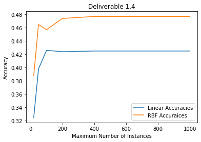

```python
# code for 1.4 here
warnings.filterwarnings('ignore')
N = [20,50,100,200,400,800,1000]
linear_acc = []
rbf_acc = []
for i in N:
    linear = SVC(kernel="linear", C=0.001, random_state=123, max_iter = i)
    rbf = SVC(kernel="rbf", C=10, random_state=123, gamma="scale", max_iter = i)
    linear.fit(X,Y)
    rbf.fit(X,Y)
    linear_acc.append(accuracy_score(Y_test, linear.predict(X_test)))
    rbf_acc.append(accuracy_score(Y_test, rbf.predict(X_test)))


plt.plot(N, linear_acc, label = "Linear Accuracies")
plt.plot(N, rbf_acc, label = "RBF Accuraices")
plt.xlabel('Maximum Number of Instances')
plt.ylabel('Accuracy')
plt.title('Deliverable 1.4')
plt.legend()
plt.show()
```

In class, we learned that the RBF kernel has a hyperparameter $\gamma$ which can affect overfitting. You can set the value of $\gamma$ with the keyword argument `gamma`.

For these experiments with `gamma`, it is preferred that you use all 1000 training instances.

#### Deliverable 1.6:

Train an RBF SVM (with $C=10.0$) where `gamma` is each of: [`1e-2`, `1e-3`, `1e-4`, `1e-5`, `1e-6`, `1e-7`], where `1eM` is scientific notation meaning $1 \times 10^M$. For each value of `gamma`, compute both the training accuracy and test accuracy. Record the values in the table below:

```python
# code for 1.6 here
gamma_rbf =  [1e-2, 1e-3, 1e-4, 1e-5, 1e-6, 1e-7]
test_acc = []
train_acc = []
for i in gamma_rbf:
    rbf = SVC(kernel="rbf", C=10.0, random_state=123, gamma=i, max_iter = 1000)
    linear.fit(X,Y)
    rbf.fit(X,Y)
    test_acc.append(accuracy_score(Y_test, rbf.predict(X_test)))
    train_acc.append(accuracy_score(Y, rbf.predict(X)))

Deliverable_1_6 = pd.DataFrame(zip(gamma_rbf,train_acc,test_acc))
Deliverable_1_6.columns = ['Gamma','Training Accuracy','Test Accuracy']
display_html(Deliverable_1_6.style.set_table_attributes("style='display:inline'").set_caption('Deliverable 1.6').set_properties(**{'text-align': 'center'})._repr_html_(), raw=True)
```

Deliverable 1.6

|  | Gamma | Training Accuracy | Test Accuracy |
| --- | --- | --- | --- |
| 0 | 0.010000 | 1.000000 | 0.089000 |
| 1 | 0.001000 | 1.000000 | 0.457000 |
| 2 | 0.000100 | 0.955000 | 0.458000 |
| 3 | 0.000010 | 0.561000 | 0.405000 |
| 4 | 0.000001 | 0.168000 | 0.131000 |
| 5 | 0.000000 | 0.112000 | 0.089000 |

#### Deliverable 1.7:

Describe what you observe in the table for 1.6, describing the effect of `gamma` in terms of the bias/variance tradeoff.

### Understanding features [5604 problem; 4604 can attempt for EC]

As stated earlier, there are two types of features in the preprocessed data: DAISY features and color histogram features.

For this last SVM problem, create two additional copies of `X` and `X_test`: one that only contains the DAISY features (the first $1664$ columns of `X`), and one that only contains the histogram features (the last $320$ columns of `X`). Give the copies new variable names, because the rest of this notebook will continue to use the previous definitions of `X` and `X_test`.

Experiment with these two different feature sets. For these experiments, use a linear SVM with $C=0.001$ and an RBF SVM with $C=10.0$ and a default setting of gamma.

#### Deliverable 1.8

Compute the test accuracy when using only the DAISY features (for both linear and RBF kernels), and compute the test accuracy when using only histogram features (for both kernels). Describe what you observe. How do the two feature sets compare to each other? How do the two feature sets compare to using both types of features combined?

##### Explanation

After splitting the data, it seems the DAISY features have more impact on the accuracy of the data than the histogram features. The RBF kernal still out perfomrs the linear kernal, which is not surprising but it seems the histogram feature data impacts the data for the linear kernal slightly more than it does for the rbf kernal. The total accuracies for the linear and rbf kernals are 0.415 and 0.477 respectively when used on the same pre processed results. The test accuracies for the DAISY features are close to this, and when we include all features, the final testing accuracy is not much higher than using only DAISY features, with a 0.011 difference for the linear kernal and a 0.007 difference for the rbf kernal. Similarly, The difference between the DAISY accuracy and the Histogram accuracy is slightly larger for the rbf kernal than the linear kernal, so it would make sense the histogram accuracy would have less affect the final accuracy.

```python
# code for 1.8 here
daisy_scalar = StandardScaler()
hist_scalar = StandardScaler()
ker = ["Linear", "RBF"]
dais_acc = []
hist_acc = []

new_train = pd.read_csv('cifar_features_train.csv', header=None)
new_test = pd.read_csv('cifar_features_test.csv', header=None)


Y = new_train.iloc[0:, 0].values
Y_test = new_test.iloc[0:, 0].values

X_daisy = new_train.iloc[0:, 1:1664].values
X_hist = new_train.iloc[0:, 1665:].values
daisy_scalar.fit(X_daisy)
hist_scalar.fit(X_hist)
X_daisy = daisy_scalar.transform(X_daisy)
X_hist = hist_scalar.transform(X_hist)
X_test_daisy = new_test.iloc[0:, 1:1664].values
X_test_hist = new_test.iloc[0:, 1665:].values
daisy_scalar.fit(X_test_daisy)
hist_scalar.fit(X_test_hist)
X_test_daisy = daisy_scalar.transform(X_test_daisy)
X_test_hist = hist_scalar.transform(X_test_hist)


linear = SVC(kernel="linear", C=0.001, random_state=123, max_iter = 1000)
rbf = SVC(kernel="rbf", C=10.0, random_state=123, gamma="scale", max_iter = 1000)
linear.fit(X_daisy,Y)
dais_acc.append(accuracy_score(Y_test, linear.predict(X_test_daisy)))
linear.fit(X_hist,Y)
hist_acc.append(accuracy_score(Y_test, linear.predict(X_test_hist)))
rbf.fit(X_daisy,Y)
dais_acc.append(accuracy_score(Y_test, rbf.predict(X_test_daisy)))
rbf.fit(X_hist,Y)
hist_acc.append(accuracy_score(Y_test, rbf.predict(X_test_hist)))

Deliverable_1_8 = pd.DataFrame(zip(ker, dais_acc, hist_acc))
Deliverable_1_8.columns = ['Kernal','Test Accuracy - Daisy', 'Test Accuracy - Histogram']

display_html(Deliverable_1_8.style.set_table_attributes("style='display:inline'").set_caption('Deliverable 1.8').set_properties(**{'text-align': 'center'})._repr_html_(), raw=True)
```

Deliverable 1.8

|  | Kernal | Test Accuracy - Daisy | Test Accuracy - Histogram |
| --- | --- | --- | --- |
| 0 | Linear | 0.404000 | 0.251000 |
| 1 | RBF | 0.470000 | 0.302000 |

## Problem 2: Decision Trees

Let's now experiment with decision tree classification on the preprocessed data using `sklearn`'s [`DecisionTreeClassifier`](http://scikit-learn.org/stable/modules/generated/sklearn.tree.DecisionTreeClassifier.html) class.

There are a variety of hyperparameters that can be adjusted to control the bias/variance tradeoff. We will experiment with two:

- `max_depth` is the maximum depth of the decision tree, as we learned about in class.
- `min_samples_leaf` is the minimum number of training instances that must be remaining at a leaf node to make a final prediction. If the algorithm tries to split a node and fewer than this minimum instances would end up in the leaf, then the algorithm will stop expanding down that path.

As with SVMs, a bit of code is in the cell below to help you get started.

```python
# code for 2.1 here
md = [3,8,14,100]
msl = [1,5,10,15,50]
md_l = []
msl_l = []
clf_test_acc = []
clf_train_acc = []

for i in md:
    for z in msl:
        clf = DecisionTreeClassifier(max_depth=i, min_samples_leaf=z, random_state=123)
        clf.fit(X,Y)
        clf_train_acc.append(accuracy_score(Y, clf.predict(X)))
        clf_test_acc.append(accuracy_score(Y_test, clf.predict(X_test)))
        md_l.append(i)
        msl_l.append(z)

Deliverable_2_1 = pd.DataFrame(zip(md_l, msl_l, clf_train_acc, clf_test_acc))
Deliverable_2_1.columns = ['Max Depth','Min Samples Leaf', 'Training Accuracy', 'Test Accuracy']
```

#### Deliverable 2.1

Experiment with setting `max_depth` to each of $[3, 8, 14, 100]$ and setting `min_samples_leaf` to each of $[1, 5, 10, 15, 50]$. For each combination of these two hyperparameters, record the training and test accuracies in the large table below. It will take a few minutes to do all of these combinations.

```python
display_html(Deliverable_2_1.style.set_table_attributes("style='display:inline'").set_caption('Deliverable 2.1').set_properties(**{'text-align': 'center'})._repr_html_(), raw=True)
```

Deliverable 2.1

|  | Max Depth | Min Samples Leaf | Training Accuracy | Test Accuracy |
| --- | --- | --- | --- | --- |
| 0 | 3 | 1 | 0.305000 | 0.248000 |
| 1 | 3 | 5 | 0.305000 | 0.248000 |
| 2 | 3 | 10 | 0.304000 | 0.248000 |
| 3 | 3 | 15 | 0.301000 | 0.250000 |
| 4 | 3 | 50 | 0.301000 | 0.241000 |
| 5 | 8 | 1 | 0.645000 | 0.263000 |
| 6 | 8 | 5 | 0.589000 | 0.261000 |
| 7 | 8 | 10 | 0.553000 | 0.282000 |
| 8 | 8 | 15 | 0.532000 | 0.278000 |
| 9 | 8 | 50 | 0.397000 | 0.283000 |
| 10 | 14 | 1 | 0.968000 | 0.258000 |
| 11 | 14 | 5 | 0.782000 | 0.250000 |
| 12 | 14 | 10 | 0.630000 | 0.282000 |
| 13 | 14 | 15 | 0.552000 | 0.273000 |
| 14 | 14 | 50 | 0.397000 | 0.283000 |
| 15 | 100 | 1 | 1.000000 | 0.242000 |
| 16 | 100 | 5 | 0.784000 | 0.254000 |
| 17 | 100 | 10 | 0.630000 | 0.282000 |
| 18 | 100 | 15 | 0.552000 | 0.273000 |
| 19 | 100 | 50 | 0.397000 | 0.283000 |

#### Deliverable 2.2

Based on your observations, as well as what you know about these two hyperparameters, describe the effects of `max_depth` and `min_samples_leaf` on the classifier performance and bias/variance tradeoff, including anything you observe about particular combinations of the two hyperparameters.

###### Answer 2.2:

It seems decision trees do not perform especially well on this dataset. In class, we learned that *random forests* can combine a number of different decision trees to improve performance. This is easy to run in `sklearn` with the [`RandomForestClassifier`](http://scikit-learn.org/stable/modules/generated/sklearn.ensemble.RandomForestClassifier.html) class. It uses most of the arguments that `DecisionTreeClassifier` supports. The argument `n_estimators` specifies the number of decision trees to train.

```python
# code for 2.3 here
estimators = [10,50,100,300]
t_acc = []

for i in estimators:
    clf = RandomForestClassifier(n_estimators=i, max_depth=100, min_samples_leaf=50, random_state=123)
    clf.fit(X,Y)
    t_acc.append(accuracy_score(Y_test, clf.predict(X_test)))

Deliverable_2_3 = pd.DataFrame(zip(estimators, t_acc))
Deliverable_2_3.columns = ['N Estimators','Test Accuracy']
```

#### Deliverable 2.3

Train a random forest using the best settings of `max_depth` and `min_samples_leaf` from 2.1 (best setting by test accuracy) and record the test accuracies in the table below. Set `n_estimators` to each of $[10, 50, 100, 300]$. You should see a substantial increase in accuracy over using an individual decision tree.

```python
display_html(Deliverable_2_3.style.set_table_attributes("style='display:inline'").set_caption('Deliverable 2.3').set_properties(**{'text-align': 'center'})._repr_html_(), raw=True)
```

Deliverable 2.3

|  | N Estimators | Test Accuracy |
| --- | --- | --- |
| 0 | 10 | 0.330000 |
| 1 | 50 | 0.374000 |
| 2 | 100 | 0.373000 |
| 3 | 300 | 0.372000 |